# Presentation on the Arrow-Pratt Measure of Risk Aversion

# Last Updated: December 14, 2021

$$\newcommand{\C}{\mathbb{C}} \newcommand{\R}{\mathbb{R}}\newcommand{\Z}{\mathbb{Z}} \newcommand{\Q}{\mathbb{Q}}\newcommand{\F}{\mathbb{F}} \newcommand{\N}{\mathbb{N}}$$

### Introduction

The Arrow-Pratt risk aversion measurement arose from Arrow (1965) and Pratt (1964); the desire was to develop a means to discern the risk aversion of Von Neumann-Morgenstern Utility functions, as well as to further expand the utility of Von Neumann-Morgenstern utility functions in Risk and Uncertainty research.  
Though by the 1960s Risk and Uncertainty research made great thrives beyond Henry Markowitz's Mean-variance analysis and optimization, as found in Markowitz [(1952)](https://www.jstor.org/stable/2975974?seq=1#metadata_info_tab_contents) and Markowitz [(1959)](https://link.springer.com/chapter/10.1007/978-1-349-20213-3_21), which were both significant contributions to the Risk and Uncertainty field. Furthermore Mean-variance analysis and optimitization found its stride in Finance's Modern Portfolio Theory, where variance minimization and expected value maximization are the intented objectives. On ther other hand Arrow-Pratt risk aversion measurement found use in Economics Portfolio Theory, where schemes were modelled with risk averse VNM utility functions, and the objective was to maximize expected utility, and thus minimize risk premium by the implicit inverse relation found in risk averse VNM utility functions (e.g., Expected Utility increases, risk premium decreases, and vice versa).  
This relationship is only true for risk adverse VNM utility functions, and not true for risk loving or risk indifferent VNM utility functions. It is not clear now, but risk adverse VNM utility funcions desire to minimize risk premium exposure, and thus seek out expected payment outcomes, or low variance lotteries. And therefore no external mechanism is required to incentative such a person to reduce their risk exposure, and therefore we can limit the problem to expected utility maximization and decision-preference, such as, Stochastic Dominance Theory, Hadar and Russell [(1971)](https://www.sciencedirect.com/science/article/pii/002205317190024X), [(1974)](https://www.sciencedirect.com/science/article/pii/0022053174900945).  
Now let begin with what is a Von Neumann-Morgenstern (VNM) Utility Function, then move into Arrow-Pratt Risk aversion, then a demonstrational example of Arrow-Pratt measure with a VNM utility function.

### Von Neumann-Morgenstern Utility Functions

If one is to understand VNM utility functions, one needs to understand the underlying theory that allow an Economist to make such a classification. Specifically VNM Theorem is based upon four axioms, Completeness, Transitivity, Continuity and Independence:

> **The Axioms of VNM-rationality**

**Axiom 1 (Completeness):** For any lotteries $L$, $M$, exactly one of the following holds:

> $$L \prec M, \; M \prec L, \; \text{ or } L \sim M$$

> (either M is preferred, L is preferred, or the individual is indifferent).

> **Axiom 2 (Transitivity):** If $L \prec M$ and $M \prec N$, then $L \prec N$, and similarly for $\sim$.

> (Preferences are consistent across any three options)

> **Axiom 3 - (a) (Continuity):** If $L \preceq M \preceq N$, then there exists a probability $p \in [0,1]$ such that

> $$pL+(1-p)N \sim M$$

> where the notation on the left side refers to a situation in which $L$ is received with probability $p$ and $N$ is recived with probability $(1-p)$.

> (Continuity assumes that there is a "tipping point" between being better than and worse than a given middle option).

> **Axiom 3 - (b) (Archimedean property):** If $L \prec M \prec N$, then there exists a probability $\varepsilon \in [0,1]$ such that

> $$(1-\varepsilon)L + \varepsilon N \prec M \prec \varepsilon L + (1-\varepsilon)N$$

> (any separation in preference can be maintained under a sufficiently small deviation in probabilities)

> **Axiom 4 - (a) (Independence):** For any $N$ and $p \in [0,1]$,

> $$L \preceq M \; \text{ iff } \; pL+(1-p)N \preceq pM+(1-p)N.$$

> The independence axiom implies the axiom on reduction of compound lotteries.

> **Axiom 4 - (b) (Reduction of compound lotteries):** For any lotteries $L$, $L^{'}$, $N$, $N^{'}$ and any $p$,$q \in [0,1]$.

> $\text{If} \quad L ~ qL^{'}+(1-q)N^{'},$ $\text{Then} \quad pL+(1-p)N ~ pqL^{'}+p(1-q)N^{'}+(1-p)N.$

> Wikipedia: [Von Neumann-morganstern Utility Theorem](https://en.wikipedia.org/wiki/Von_Neumann%E2%80%93Morgenstern_utility_theorem)

With the following four axioms established, one can now understand the role that VNM Theorem plays in Risk and Uncertainty research. The theorem itself describes rationality of a VNM-rational agent, and the condition that are need to describe an agent as VNM-rational.

> **The VNM Theorem:**

For any VNM-rational agent (i.e. satisfying axioms 1–4), there exists a function $u$ which assigns to each outcome $A$ a real number $u(A)$ such that for any two lotteries,

> $$L \prec M \text{ iff } E[u(L)] < E[u(M)],$$

> where $E[u(L)]$, or more briefly $Eu[L]$ is given by,

> $$Eu[p_{1}A_{1} + \cdots + p_{n}A_{n}] = p_{1}u(A_{1}) + \cdots + p_{n}u(A_{n}).$$

> As such, $u$ can be uniquely determined (up to adding a constant and multiplying by a positive scalar) by preferences between simple lotteries, meaning those of the form $pA + (1 − p)B$ having only two outcomes. Conversely, any agent acting to maximize the expectation of a function $u$ will obey axioms 1–4. Such a function is called the agent's **von Neumann–Morgenstern (VNM) utility**.

> Wikipedia: [Von Neumann-morganstern Utility Theorem](https://en.wikipedia.org/wiki/Von_Neumann%E2%80%93Morgenstern_utility_theorem)

The following functions are classified as Von Neumann-Morgenstern Utility functions, and are now quite fame functions in the field of Risk and Uncertainty, as each of these function could be found in Insurance, Portfolio Theory, Preference Choice and other risk and uncertainty topics.

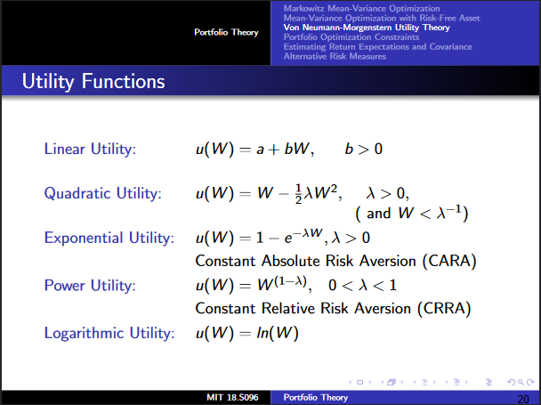

Credit:[Lecture 14: Portfolio Theory](https://ocw.mit.edu/courses/mathematics/18-s096-topics-in-mathematics-with-applications-in-finance-fall-2013/lecture-notes/MIT18_S096F13_lecnote14.pdf) MIT 18.S096 Dr. Kempthorne Fall 2013

Note that VNM theorem does not imply a difference in VNM-rational agents, and specifically does not imply degrees of risk aversion amongst these VNM-rational agents, in fact VNM Theorem is only a classifying theorem for the collection of functions that can be described as VNM-rational agents in experimentations. For a classification of risk aversion amongst VNM-rational agents, one must look towards Arrow-Pratts Risk Aversion; it is a measurement for the risk aversion of VNM-rational functions.

### Arrow-Pratt Risk Aversion

Though we articulated an appropriate theoretical framework for VNM utility function, it is sorely lacking in Real Analysis, and matter fact it is sorely lacking in the calculus framework to derive the Arrow-Pratt measurement. So we will begin by redefining VNM-utility function in ther terms of Real Analysis.  
We know that $U: \R^{+} \to \R$, for all VNM utility functions. But let choose a power utility defined by $\lambda = \frac{1}{2}$, so we get $u(x)=x^{\frac{1}{2}}$. To first we need to prove is continuity on $\R$.

**PROOF.**  
Let $U(x)=x^{\frac{1}{2}}$. Suppose $\varepsilon > 0$, and define $\delta = 2\varepsilon$. As $\varepsilon \in \R$, then $2\varepsilon \in \R$ and $2\varepsilon > 0$. Let $X,c \in \R^{+}$. Assume $|x-c| < \delta$. Then

$$\big|U(x)-U(c)\big| = \big|\sqrt{x} - \sqrt{c}\big| = (\sqrt{x} - \sqrt{c})\cdot \frac{\sqrt{x} + \sqrt{c}}{\sqrt{x} + \sqrt{c}}$$$$=\frac{x-c}{\sqrt{x} - \sqrt{c}} \leq \frac{x-c}{2} < \frac{\delta}{2} = \frac{2\varepsilon}{2} = \varepsilon$$

Hence $U$ is continuous at $c \in \R^{+}$, and therefore is $U$ is continuous on $\R^{+}$.

The second condition, we need to prove that $U$ is twice differentiable.

**PROOF.**  
Let $U(x)=x^{\frac{1}{2}}$, $\forall x \in \R^{+}$.

$$\lim_{h \to 0} \frac{U(x+h)-U(x)}{h} = \lim_{h \to 0} \frac{\sqrt{x+h}-\sqrt{x}}{h} = \lim_{h \to 0} \frac{\sqrt{x+h}-\sqrt{x}}{h} \cdot \frac{\sqrt{x+h}+\sqrt{x}}{\sqrt{x+h}+\sqrt{x}}$$$$=\lim_{h \to 0} \frac{x+h-x}{h\big[\sqrt{x+h}+\sqrt{x}\big]}==\lim_{h \to 0} \frac{h}{h\big[\sqrt{x+h}+\sqrt{x}\big]} = =\lim_{h \to 0} \frac{1}{\sqrt{x+h}+\sqrt{x}}$$$$=\frac{1}{\sqrt{x}+\sqrt{x}} = \frac{1}{2\sqrt{x}}$$

Hence $U$ is differentiable on $\R^{+}$. $\square$

We need to prove that $U$ has a second derivative.

**PROOF.**  
Let $U^{'}(x)=\frac{1}{2\sqrt{x}}$, $\forall x \in \R^{+}$.

$$\lim_{h \to 0} \frac{U(x+h)-U(x)}{h} = \lim_{h \to 0} \frac{\frac{1}{2\sqrt{x+h}}-\frac{1}{2\sqrt{x}}}{h} = \lim_{h \to 0} \frac{\frac{1}{2\sqrt{x+h}}-\frac{1}{2\sqrt{x}}}{h} \cdot \frac{4(x+h)-4x}{4(x+h)-4x}$$$$= \lim_{h \to 0} \frac{2(\sqrt{x+h}-\sqrt{x})}{h[4(h+x)-4x]} = \lim_{h \to 0} \frac{2(\sqrt{x+h}-\sqrt{x})}{h[4(h+x)-4x]} \cdot \frac{\sqrt{x+h}+\sqrt{x}}{\sqrt{x+h}+\sqrt{x}}$$$$= \lim_{h \to 0} \frac{2(x+h-x)}{h[-4(x+h)^{\frac{3}{2}}-4(x)^{\frac{3}{2}}]} = \lim_{h \to 0} \frac{2h}{h[-4(x+h)^{\frac{3}{2}}-4(x)^{\frac{3}{2}}]} = \lim_{h \to 0} \frac{2}{-4(x+h)^{\frac{3}{2}}-4(x)^{\frac{3}{2}}}$$$$= \frac{2}{-4(x)^{\frac{3}{2}}-4(x)^{\frac{3}{2}}} = - \frac{2}{8(x)^{\frac{3}{2}}} = - \frac{1}{4x^{\frac{3}{2}}}$$

Hence $U$ possesses a second derivative, and thus is twice differentiable. $\square$

Now we have to prove that $U^{'}(x)$ is strictly decreasing and concave.

**PROOF.**  
Suppose $U(x)=\sqrt{x}$, which is defined on $\R^{+}$. We can observe that $U$ is strictly increasing on $\forall x \in \R^{+}$. From the above proof, we proved that the second derivative of $U$ is $U^{''}(x)=- \frac{1}{4x^{\frac{3}{2}}}$; we can observe that $U^{''}(x)$ is strictly decreasing on $\forall x \in \R^{+}$ From Derivative of Monotonic Function ([Wikipedia: Derivative of Monotonic Function](https://proofwiki.org/wiki/Derivative_of_Monotone_Function  
)), $U^{'}=\frac{1}{2\sqrt{x}}$ is strictly decreasing on $\forall x \in \R^{+}$. Hence as found in [Wikipedia: Real Function is Strictly Concave iff Derivative is Strictly Decreasing](https://proofwiki.org/wiki/Real_Function_is_Strictly_Concave_iff_Derivative_is_Strictly_Decreasing) , because $U^{'}(x)$ is strictly decreasing, that implies that $U(x)$ as a real-value function is strictly concave on $\R^{+}$. $\square$

**PROOF.**  
Suppose $U(x)=\sqrt{x}$, which is defined on $\R^{+}$. The first derivative of $U(x)$ is $U^{'}(x)=\frac{1}{2\sqrt{x}}$. Hence,

$$\lim_{x \to 0^{+}} U^{'}(x) = \lim_{x \to 0^{+}} \frac{1}{2\sqrt{x}} = \frac{\lim_{x \to 0^{+}} 1 }{\lim_{x \to 0^{+}} (2\sqrt{x})}= \frac{\lim_{x \to 0^{+}} 1 }{\lim_{x \to 0^{+}} 2 \cdot \lim_{x \to 0^{+}} \sqrt{x}}$$$$\frac{1}{2*0} = \frac{1}{0} = \infty.$$

As well,

$$\lim_{x \to \infty} U^{'}(x) = \lim_{x \to \infty} \frac{1}{2\sqrt{x}} = \frac{\lim_{x \to \infty} 1 }{\lim_{x \to \infty} (2\sqrt{x})}= \frac{\lim_{x \to 0^{+}} 1 }{\lim_{x \to \infty} 2 \cdot \lim_{x \to \infty} \sqrt{x}}$$$$\frac{1}{2*\infty} = \frac{1}{\infty} = 0.$$

Therefore Inada conditions are satisfied by $U$. $\square$

[figure not shown]

Credit:[Evolution of the Arrow–Pratt measure of risk-tolerance for predictable forward utility processes by Moris S. Strub and Xun Yu Zhou](https://ocw.mit.edu/courses/mathematics/18-s096-topics-in-mathematics-with-applications-in-finance-fall-2013/lecture-notes/MIT18_S096F13_lecnote14.pdf)

Though we Finally we can construct the Arrow-Pratt measure of absolute risk aversion, as well determine the risk aversion of our $U$. Just as with VNM Utility function, $u(x)$ has to be twice differentiable and monotonically increasing real-value function, so that we get,

$$ARA(x) = -\frac{u^{''}(x)}{u^{'}(x)}.$$

When $ARA(x) < 0$, it means that NMV Utility posesseses an affinity for risk, and therefore can stomach high risk premiums in their decision-making. Risk and Uncertainty rsearchers class this type of VNM-utility function as a *risk lover*. If $ARA(x) > 0$ then the VNM utility function possesses an aversion to risk, and would prefer an expected payment over a lottery in their decision-making. Risk and Uncertainty rsearchers class this type of VNM-utility function as a *risk averse*. But when $ARA(x) = 0$, the VNM utility function possesses an indifference to any level of risk premium, and therefore is classified by Risk and Uncertainty rsearchers as *risk-neutral*, or *risk indifferent*.  
With that defined, let move on to demonstrate Arrow-Pratt measure on our slected power utility function, $U(x)=\sqrt{x}$.

### Arrow-Pratt Risk Aversion Example

$$ARA(x) = - \frac{-\frac{1}{4x^{\frac{3}{2}}}}{\frac{1}{2\sqrt{x}}}=\frac{1}{2x}.$$

We can observe that our utility function is risk-averse, because it possesses an positive, $ARA > 0$, absolute risk aversion. We can therefore conclude that persons that possess this particular utility functon are averse to risk, and are motivated to seek out expected outcomes over lottery outcome in their decision-preference.

### Reference Page

- https://second.wiki/wiki/arrow-pratt-mac39f
- http://www.columbia.edu/~xz2574/download/SZ.pdf
- https://www.econport.org/econport/request?page=man_ru_advanced_riskaversion
- https://en.wikipedia.org/wiki/Von_Neumann%E2%80%93Morgenstern_utility_theorem
- https://www.sciencedirect.com/science/article/pii/0022053174900945
- https://www.sciencedirect.com/science/article/pii/002205317190024X
- https://www.jstor.org/stable/2975974?seq=1#metadata_info_tab_contents